# ExperimentalDesign

Bin Li

# 1 Objectives of the Experiment

The objective of the experiment is to investigate the effects of dry yeast amount on dough rising. This idea comes from our daily impression and life experience that the amount of yeast generally has a positive impact on dough rising. By setting the null hypothesis of equal means of different levels of yeast, we try to discover the detailed relation, if any.

# 2 Experiment Design Details

**Treatment Factors**  
Treatments: four levels of dry yeast amount (1/8 teaspoon, ¼ teaspoon, ½ teaspoon, and 1 teaspoon).

**Experimental Units**  
Experimental units: shares of dough, each contains 100g flour and 55g water.

**Blocking Factor**  
Blocking factor: experimenters in different location due to the pandemic.

**Response Measurements**  
Response Variable: diameter of the dough

**Model**

$Y_{ijk}$ = $\mu$ + $\tau_{i}$ + $\beta_{j}$ + $\epsilon_{ijk}$

where $Y_{ijk}$ is the response, diameter of the dough after rising  
$\mu$ is the overall mean  
$\tau_{i}$ is the treatment effects  
$\beta_{j}$ is block effect  
$\epsilon_{ijk}$ is the normal error terms

**Pilot Study and Power Analysis**

# 3 Analysis

## 3.1 Hypotheses

$H_{0}$: $\tau_{1}$ = $\tau_{2}$ = $\tau_{3}$ = $\tau_{4}$ $H_{a}$: At leaset two $\tau_{i}$ differ.

## 3.2 Test

**Read data**

```r
library(tidyverse)
doughrising = read.csv("/Volumes/LI/MU/STA566/Project/DoughRising.csv", head = TRUE)
head(doughrising)
```

```
##   Runs Block Treatment Diameter
## 1    1   Wen       1.0     11.0
## 2    2   Wen       1.0     10.8
## 3    3   Wen       1.0     10.6
## 4    4   Wen       1.0     10.5
## 5    5   Wen       0.5     10.0
## 6    6   Wen       0.5     10.1
```

```r
doughrising = doughrising %>%
  mutate(Block = factor(Block),
         Treatment = factor(Treatment))
```

### 3.2.1 Summary Statistics

1. Response variable grouped by Treatment groups  
   For the treatment output, we can see the mean diameter is increasing as the amount of yeast goes up. The variance in the middle two groups is smaller than the other two. We might need to check the variance in the model assumption section.

```r
library(dplyr)
doughrising %>% group_by(Treatment) %>%
  summarise(N = n(),
            Mean = mean(Diameter),
            SD= sd(Diameter),
            Min = min(Diameter),
            Max = max(Diameter))
```

```
## # A tibble: 4 × 6
##   Treatment     N  Mean    SD   Min   Max
##   <fct>     <int> <dbl> <dbl> <dbl> <dbl>
## 1 0.125         8  9.01 0.422   8.5   9.8
## 2 0.25          8  9.64 0.245   9.2  10
## 3 0.5           8 10.0  0.267   9.6  10.4
## 4 1             8 11.0  0.430  10.5  11.7
```

2. Response variable grouped by Block  
   The mean diameters in the blocks are very similar. The variance is a little bit different.

```r
doughrising %>% group_by(Block) %>%
  summarise(N = n(),
            Mean = mean(Diameter),
            SD= sd(Diameter),
            Min = min(Diameter),
            Max = max(Diameter))
```

```
## # A tibble: 2 × 6
##   Block     N  Mean    SD   Min   Max
##   <fct> <int> <dbl> <dbl> <dbl> <dbl>
## 1 Bin      16  9.99 0.988   8.5  11.7
## 2 Wen      16  9.87 0.623   8.9  11
```

3. Boxplots  
   The boxplots correspond to the summary statistics above. In the first boxplot, a clear positive relationship can be observed between treatment and diameter. The second one shows the block factor: the mean and median of the two blocks are very similar, and difference in variance is identified.

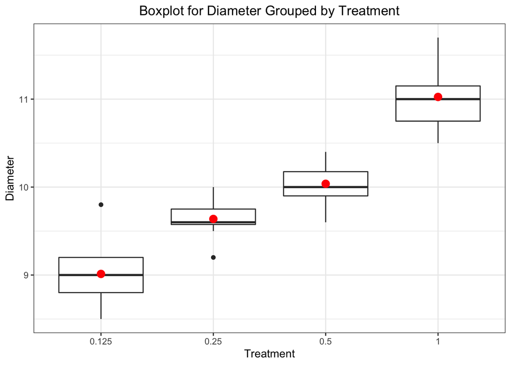

```r
library(ggplot2)
ggplot(aes(x = Treatment, y = Diameter), data = doughrising) +
  geom_boxplot() +
  labs(title = "Boxplot for Diameter Grouped by Treatment") +
  stat_summary(fun.y=mean, geom="point", shape=20, size=5, color="red", fill="red") +
  theme_bw() +
  theme(plot.title = element_text(hjust = 0.5))
```

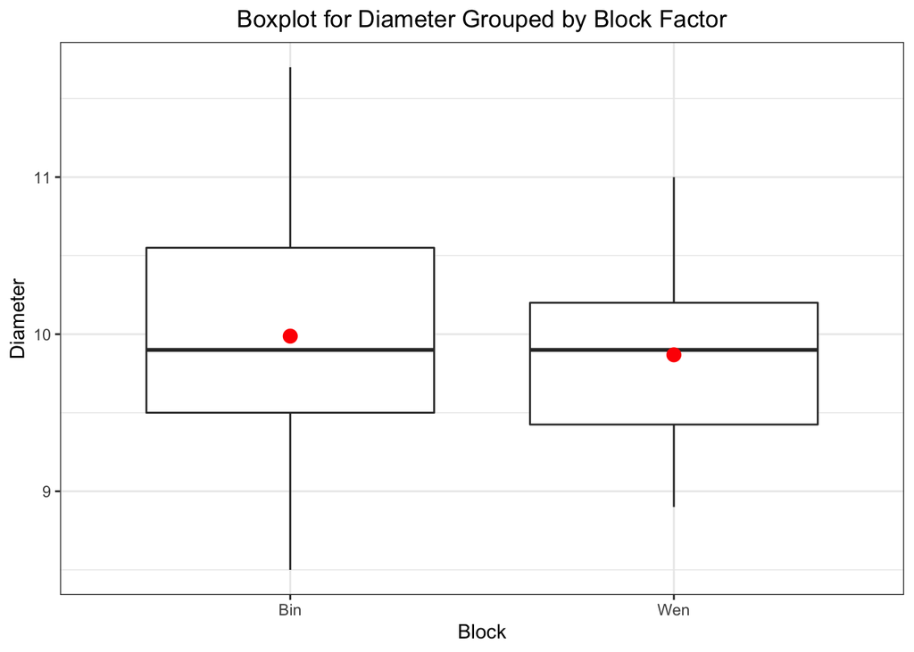

```r
ggplot(aes(x = Block, y = Diameter), data = doughrising) +
  geom_boxplot() +
  labs(title = "Boxplot for Diameter Grouped by Block Factor") +
  stat_summary(fun.y=mean, geom="point", shape=20, size=5, color="red", fill="red") +
  theme_bw() +
  theme(plot.title = element_text(hjust = 0.5))
```

### 3.2.2 ANOVA Test

From the ANOVA table, we can see that the P-value of our treatment factor is very small, indicating we need to reject our null hypothesis of equal treatment effects. In fact, results indicate that the amount of dry yeast does affect the diameter/size of the rising dough. At the same time, the table tells us that the block factor is not significant thus we do not need to worry about it.

```r
aov.fit = aov(Diameter ~ Treatment + Block, data = doughrising)
summary(aov.fit)
```

```
##             Df Sum Sq Mean Sq F value   Pr(>F)
## Treatment    3 17.103   5.701   45.97 9.64e-11 ***
## Block        1  0.113   0.113    0.91    0.349
## Residuals   27  3.348   0.124
## ---
## Signif. codes:  0 '***' 0.001 '**' 0.01 '*' 0.05 '.' 0.1 ' ' 1
```

### 3.2.3 Multiple Comparison

The results of multiple comparison adjusted by Tukey’s Method is shown below. The estimate of differences of least square means between 1⁄2 teaspoon and 1⁄4 teaspoon groups is small and the large p-value suggests that this pair is not significantly different, whereas all of the other pair-wise comparisons are significant with small p-values.

```r
TukeyHSD(aov.fit)
```

```
##   Tukey multiple comparisons of means
##     95% family-wise confidence level
##
## Fit: aov(formula = Diameter ~ Treatment + Block, data = doughrising)
##
## $Treatment
##              diff         lwr       upr     p adj
## 0.25-0.125 0.6250  0.14314676 1.1068532 0.0073896
## 0.5-0.125  1.0250  0.54314676 1.5068532 0.0000193
## 1-0.125    2.0125  1.53064676 2.4943532 0.0000000
## 0.5-0.25   0.4000 -0.08185324 0.8818532 0.1299947
## 1-0.25     1.3875  0.90564676 1.8693532 0.0000001
## 1-0.5      0.9875  0.50564676 1.4693532 0.0000339
##
## $Block
##             diff        lwr       upr     p adj
## Wen-Bin -0.11875 -0.3742175 0.1367175 0.3486663
```

### 3.2.4 Checking Model Assumption

1. Constant Variance  
   Residuals do not seem to vary with respect to the predicted mean, thus the constant variance assumption is not violated.

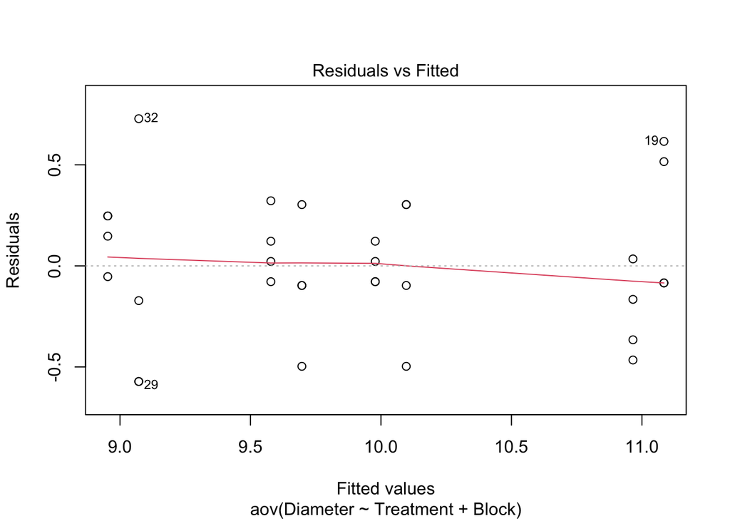

```r
library(car)
plot(aov.fit,1)
```

```r
leveneTest(Diameter ~ Treatment , data = doughrising)
```

```
## Levene's Test for Homogeneity of Variance (center = median)
##       Df F value Pr(>F)
## group  3  0.8791 0.4637
##       28
```

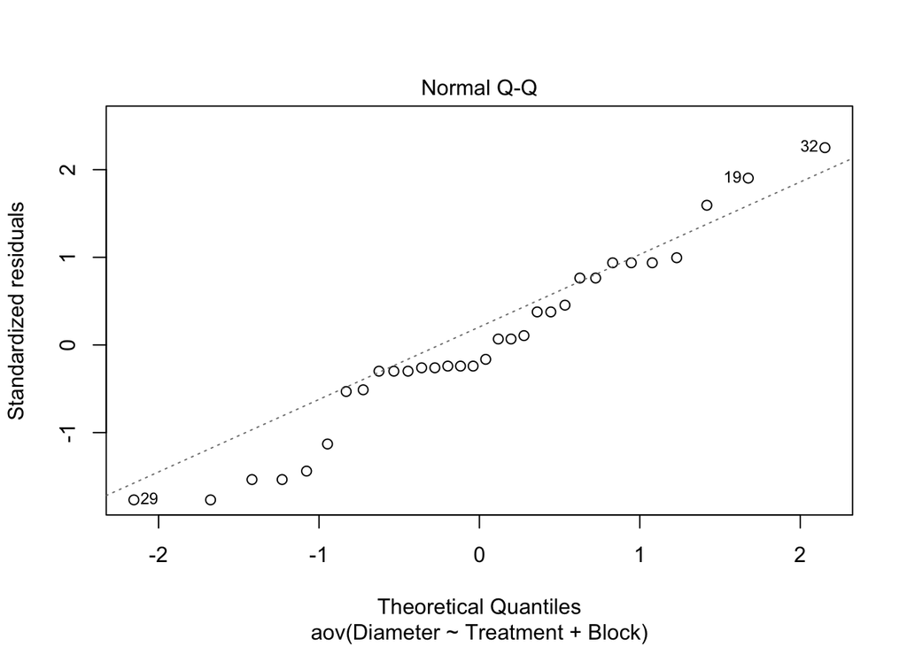

```r
plot(aov.fit, 2)
```

```r
# Extract the residuals
aov.residuals <- residuals(object = aov.fit )
# Run Shapiro-Wilk test
shapiro.test(x = aov.residuals )
```

```
##
##  Shapiro-Wilk normality test
##
## data:  aov.residuals
## W = 0.96099, p-value = 0.2923
```

3. Linearity  
   No distinct pattern is identified in the residual vs. predicted mean, linearity holds.
4. Outliers  
   All residuals are distributed within ±3 SD, and there is no evident outlier.
5. Independence  
   Independence is Guaranteed by the design of the experiment.

## 3.3 Conclusion

Based on the statistical analysis, we conclude that the amount of dry yeast affects the diameter/size of rising dough. Under our experiment conditions (100g flour and 55g water), although the statistical difference between the diameter of the rising dough of 1⁄4 tsp yeast and 1⁄2 tsp group is not identified, all other groups have significant differences. From the boxplots, there seems to be a positive relationship between the amount of yeast and the diameter. The detailed relationship between the two is subject to further analysis.

# 4 Note

This is a course project done by Bin Li and Wen Pan.